# A new alternative to determine weed control in agricultural systems based on artificial neural networks (ANNs) - ScienceDirect

[figure not shown]

## Outline

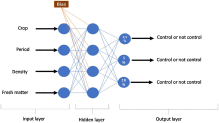

## Extras (1)

[figure not shown]

## [Field Crops Research](https://www.sciencedirect.com/journal/field-crops-research)

[Volume 263](https://www.sciencedirect.com/journal/field-crops-research/vol/263/suppl/C), 1 April 2021, 108075

# A new alternative to determine weed control in agricultural systems based on artificial neural networks (ANNs)

[Alex LimaMonteiro](https://www.sciencedirect.com/science/article/abs/pii/S0378429021000216#!)[Matheus deFreitas Souza](https://www.sciencedirect.com/science/article/abs/pii/S0378429021000216#!)[Hamurábi AnizioLins](https://www.sciencedirect.com/science/article/abs/pii/S0378429021000216#!)[Taliane Maria da SilvaTeófilo](https://www.sciencedirect.com/science/article/abs/pii/S0378429021000216#!)[Aurélio PaesBarros Júnior](https://www.sciencedirect.com/science/article/abs/pii/S0378429021000216#!)[Daniel ValadãoSilva](https://www.sciencedirect.com/science/article/abs/pii/S0378429021000216#!)[VanderMendonça](https://www.sciencedirect.com/science/article/abs/pii/S0378429021000216#!)

https://doi.org/10.1016/j.fcr.2021.108075[Get rights and content](https://s100.copyright.com/AppDispatchServlet?publisherName=ELS&contentID=S0378429021000216&orderBeanReset=true)

## Highlights

**•**

The use of RNAs was tested to estimate the beginning of weed control considering model crops.

**•**

The ANN-MLP models were efficient in determining the ideal moment for weed control.

**•**

RNAs allow us to estimate the beginning of weed control.

**•**

Combined non-destructive and destructive entries do not require other, more specific entries.

**•**

The period is the main factor that interferes with the degree of weed interference in sesame and [melon](https://www.sciencedirect.com/topics/agricultural-and-biological-sciences/melons).

## Abstract

Weed control is a necessary practice to avoid crop yield losses. Therefore, farmers should answer the following question: when to start weed control? Currently, there are no learning models to assist the producer to answer this question. Thus, the objectives were to: 1) evaluate the ability of artificial neural networks (ANNs) to estimate the beginning of weed control for different classes of acceptable yield losses; 2) validate a new alternative for modeling and predicting competition between weeds and crops. ANNs determined the ideal moment to control weeds based on non-destructive and destructive variables. The inputs C3/C4 ratio, coexistence period, density of weeds, and crop (categorical variable to differentiate sesame and melon) provided accuracy and F-score values above 0.95 during training, validation, and testing steps for [ANN](https://www.sciencedirect.com/topics/agricultural-and-biological-sciences/neural-networks) in non-destructive method. When using the destructive variables, C3/C4 ratio plus coexistence period, fresh matter of weeds, and crop provided accuracy and F-score values above 0.90 during training, validation, and testing steps. The combination of non-destructive and destructive inputs also generated an ANN with high accuracy and F-score, above 0.95, during training, validation, and testing steps. Machine learning can be used in crop-weed competition modeling.

## Keywords

Weed interference

Artificial intelligence

Modeling

Decision making

## Cited by (6)

### Yield loss assessment of grapes using composite drought index derived from landsat OLI and TIRS datasets

- 2022, Remote Sensing Applications: Society and Environment

### Artificial-intelligence and sensing techniques for the management of insect pests and diseases in cotton: A systematic literature review

- 2022, Journal of Agricultural Science

### An effective model for predicting agricultural crop yield on remote sensing hyper-spectral images using adaptive logistic regression classifier

- 2022, Concurrency and Computation: Practice and Experience

### Weed control in melon with preemergence herbicides

- 2022, Pesquisa Agropecuaria Brasileira

### Sustainable Approach to Weed Management: The Role of Precision Weed Management

- 2022, Agronomy

### Weed interference in carrot yield in two localized irrigation systems

- 2021, Revista Caatinga

© 2021 Elsevier B.V. All rights reserved.

Citations

- Citation Indexes: 6

Captures

- Readers: 28

Social Media

[figure not shown]

[View details](https://plu.mx/plum/a/?doi=10.1016/j.fcr.2021.108075&theme=plum-sciencedirect-theme&hideUsage=true)

[figure not shown]